# Data Wrangling and Visualization in R

DSCI 632: Statistics for Data Science

Peter Ralph, University of Oregon

# Data wrangling

## Goals

We have data! We’d like to

- clean it
- organize it
- summarize it
- rearrange it

> R is the best thing in the world if you have a rectangular data frame.

A *data frame*, a.k.a. [*tidy data*](https://tidyr.tidyverse.org/), has

- columns are variables
  - all values in a column are the same type
- observations are rows

## Case study:

The PanTHERIA dataset (with cleaning code hid away in `read_pantheria`):

```r
source("../datasets/PanTHERIA/read_pantheria.R")
pantheria <- read_pantheria("../datasets/PanTHERIA")
head(pantheria)
```

```
##          Order    Family   Genus     Species            Binomial ActivityCycle AdultBodyMass_g AdultForearmLen_mm AdultHeadBodyLen_mm AgeatEyeOpening_d AgeatFirstBirth_d BasalMetRate_mLO2hr BasalMetRateMass_g
## 1 Artiodactyla Camelidae Camelus dromedarius Camelus dromedarius       diurnal       492714.47                 NA                  NA                NA           1651.62             40293.0             407000
## 2    Carnivora   Canidae   Canis     adustus       Canis adustus     nocturnal        10392.49                 NA              745.32                NA                NA                  NA                 NA
## 3    Carnivora   Canidae   Canis      aureus        Canis aureus   crepuscular         9658.70                 NA              827.53              7.50                NA                  NA                 NA
## 4    Carnivora   Canidae   Canis     latrans       Canis latrans   crepuscular        11989.10                 NA              872.39             11.94            365.00              3699.0              10450
## 5    Carnivora   Canidae   Canis       lupus         Canis lupus   crepuscular        31756.51                 NA             1055.00             14.01            547.50             11254.2              33100
## 6 Artiodactyla   Bovidae     Bos   frontalis       Bos frontalis   crepuscular       800143.05                 NA             2700.00                NA                NA                  NA                 NA
##   DietBreadth DispersalAge_d GestationLen_d HabitatBreadth HomeRange_km2 HomeRange_Indiv_km2 InterbirthInterval_d LitterSize LittersPerYear MaxLongevity_m NeonateBodyMass_g NeonateHeadBodyLen_mm
## 1           3             NA         386.51              1        196.32                  NA               614.41       0.98              1          480.0          36751.19                    NA
## 2           6         329.99          65.00              1          1.01                1.01                   NA       4.50             NA          137.0                NA                    NA
## 3           6             NA          61.24              1          2.95                3.13               365.00       3.74             NA          192.0            211.82                    NA
## 4           1         255.00          61.74              1         18.88               19.91               365.00       5.72             NA          262.0            200.01                    NA
## 5           1         180.00          63.50              1        159.86               43.13               365.00       4.98              2          354.0            412.31                    NA
## 6           3             NA         273.75             NA            NA                  NA               403.02       1.22              1          314.4          22977.05                    NA
##   PopulationDensity_n/km2 PopulationGrpSize SexualMaturityAge_d SocialGrpSize TeatNumber Terrestriality TrophicLevel WeaningAge_d WeaningBodyMass_g WeaningHeadBodyLen_mm
## 1                    0.98                11             1947.94            10         NA      fossorial    herbivore       389.38                NA                    NA
## 2                    0.74                NA              249.88            NA          8      fossorial     omnivore        52.89                NA                    NA
## 3                    0.22                NA              371.23            NA          8      fossorial     omnivore        61.30                NA                    NA
## 4                    0.25                NA              372.90            NA          8      fossorial    carnivore        43.71                NA                    NA
## 5                    0.01                NA              679.37            NA          9      fossorial    carnivore        44.82                NA                    NA
## 6                    0.54                NA              610.97            40         NA           <NA>    herbivore       186.67                NA                    NA
```

## Dialects of R

“Base R” is, mostly, R that you get without loading packages.

“The [tidyverse](https://tidyverse.org)” is a collection of packages with a coherent design philosophy that streamlines a bunch of common operations. (Load it with `library(tidyverse)`.)

Just like a verbal language, there’s a soft distinction between these, and they intermix a great deal.

## For instance:

How many species in each order?

```r
table(pantheria$Order)
```

```
##
##     Afrosoricida     Artiodactyla        Carnivora          Cetacea       Chiroptera        Cingulata   Dasyuromorphia       Dermoptera  Didelphimorphia    Diprotodontia   Erinaceomorpha       Hyracoidea
##               51              240              286               84             1116               21               71                2               87              143               24                4
##       Lagomorpha    Macroscelidea   Microbiotheria      Monotremata Notoryctemorphia Paucituberculata  Peramelemorphia   Perissodactyla        Pholidota           Pilosa         Primates      Proboscidea
##               92               15                1                5                2                6               21               17                8               10              376                3
##         Rodentia       Scandentia          Sirenia     Soricomorpha    Tubulidentata
##             2277               20                5              428                1
```

```r
pantheria |> summarise(n=n(), .by=Order)
```

```
##               Order    n
## 1      Artiodactyla  240
## 2         Carnivora  286
## 3          Primates  376
## 4   Didelphimorphia   87
## 5         Cingulata   21
## 6          Rodentia 2277
## 7           Cetacea   84
## 8    Erinaceomorpha   24
## 9     Diprotodontia  143
## 10       Chiroptera 1116
## 11   Perissodactyla   17
## 12  Peramelemorphia   21
## 13     Soricomorpha  428
## 14     Afrosoricida   51
## 15       Scandentia   20
## 16       Hyracoidea    4
## 17       Lagomorpha   92
## 18           Pilosa   10
## 19    Macroscelidea   15
## 20      Proboscidea    3
## 21       Dermoptera    2
## 22 Paucituberculata    6
## 23   Dasyuromorphia   71
## 24   Microbiotheria    1
## 25          Sirenia    5
## 26        Pholidota    8
## 27 Notoryctemorphia    2
## 28      Monotremata    5
## 29    Tubulidentata    1
```

Average size of cats:

```r
cats <- pantheria$Family == "Felidae"
c(
    weight=mean(pantheria$AdultBodyMass_g[cats], na.rm=TRUE),
    length=mean(pantheria$AdultHeadBodyLen_mm[cats], na.rm=TRUE)
)
```

```
##     weight     length
## 23592.3827   850.0984
```

```r
pantheria |>
    filter(Family == "Felidae") |>
    summarise(
        weight=mean(AdultBodyMass_g, na.rm=TRUE),
        length=mean(AdultHeadBodyLen_mm, na.rm=TRUE)
    )
```

```
##     weight   length
## 1 23592.38 850.0984
```

Average size of all families in Carnivora:

```r
carnivores <- droplevels(pantheria[pantheria$Order == "Carnivora",])
data.frame(
    weight=tapply(carnivores$AdultBodyMass_g, carnivores$Family, mean, na.rm=TRUE),
    length=tapply(carnivores$AdultHeadBodyLen_mm, carnivores$Family, mean, na.rm=TRUE)
) |> head()
```

```
##                weight    length
## Ailuridae    5170.080  582.3200
## Canidae      7518.692  673.0075
## Eupleridae   2280.729  421.2088
## Felidae     23592.383  850.0984
## Herpestidae  1615.528  402.7148
## Hyaenidae   37389.452 1075.2325
```

```r
pantheria |>
    filter(Order == "Carnivora") |>
    summarise(
        weight=mean(AdultBodyMass_g, na.rm=TRUE),
        length=mean(AdultHeadBodyLen_mm, na.rm=TRUE),
        .by=Family
    ) |> head()
```

```
##        Family     weight    length
## 1     Canidae   7518.692  673.0075
## 2   Otariidae 143116.831 1826.0243
## 3 Herpestidae   1615.528  402.7148
## 4    Phocidae 315876.869 2187.7616
## 5  Viverridae   3763.690  561.0057
## 6  Mustelidae   4501.205  499.3314
```

## Your turn:

Find the *average litter size* by Order.

# Visualization

## Goals

- pattern discovery
- efficient summary of information
- visual/spatial analogy for quantitative patterns

aim to *maximize information and minimize ink*

paraphrased from Edward Tufte

## Considerations

- Is the visual analogy appropriate for the *type* of data?

counts? quantities? multivariate? relationships?

- Are important *comparisons* clear?

between groups? differences? time trend?

- Are *units* easily interpretable?

meters? dollars? percent? relative change? is it isometric?

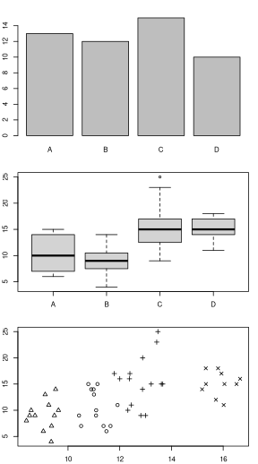

## Principles of effective display

- Show the data
- Encourage the eye to compare differences
- Represent magnitudes honestly and accurately
- Draw graphical elements clearly, minimizing clutter
- Make displays easy to interpret

> Above all else show the data.

Tufte 1983

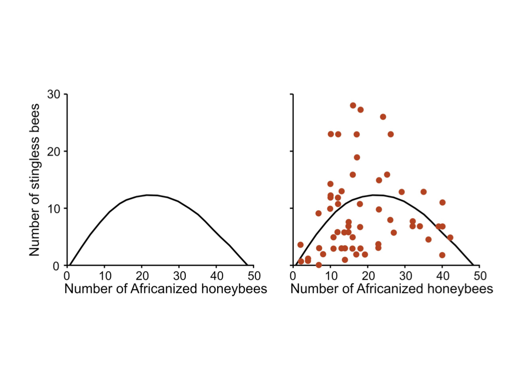

honeybees

## Think about what you want to communicate

[figure not shown]

cumulative COVID test numbers

[AP Images: Alex Brandon](http://www.apimages.com/metadata/Index/Virus-Outbreak-Trump/f2c5f8d116a24062b563a32cea88235e/1/0)

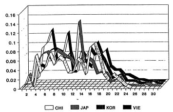

Broman’s bad graphs 1

from *Roeder K (1994), Statistical Science 9:222-278, Figure 4* via [Karl Broman](https://www.biostat.wisc.edu/~kbroman/topten_worstgraphs/)

# Case study:

## PanTHERIA

Distributions of litter sizes by Order, and Family, in the PanTHERIA dataset:

```r
# look at most common orders
order_nums <- pantheria |>
    summarise(n=n(), .by=Order) |> arrange(desc(n))
big_orders <- order_nums |> subset(n > 150) |> pull(Order)
order_nums
```

```
##               Order    n
## 1          Rodentia 2277
## 2        Chiroptera 1116
## 3      Soricomorpha  428
## 4          Primates  376
## 5         Carnivora  286
## 6      Artiodactyla  240
## 7     Diprotodontia  143
## 8        Lagomorpha   92
## 9   Didelphimorphia   87
## 10          Cetacea   84
## 11   Dasyuromorphia   71
## 12     Afrosoricida   51
## 13   Erinaceomorpha   24
## 14        Cingulata   21
## 15  Peramelemorphia   21
## 16       Scandentia   20
## 17   Perissodactyla   17
## 18    Macroscelidea   15
## 19           Pilosa   10
## 20        Pholidota    8
## 21 Paucituberculata    6
## 22          Sirenia    5
## 23      Monotremata    5
## 24       Hyracoidea    4
## 25      Proboscidea    3
## 26       Dermoptera    2
## 27 Notoryctemorphia    2
## 28   Microbiotheria    1
## 29    Tubulidentata    1
```

```r
px <- pantheria |> filter(Order %in% big_orders) |>
       filter(!is.na(LitterSize)) |>
       select(Order, Family, Genus, Species, LitterSize)
for (xn in c("Order", "Family", "Genus")) px[[xn]] <- factor(px[[xn]])
summary(px)
```

```
##           Order                  Family              Genus           Species       LitterSize
##  Artiodactyla:178   Muridae         : 242   Microtus    :  38   Length   :2060   Min.   : 0.960
##  Carnivora   :209   Cricetidae      : 239   Myotis      :  38   N.unique :1640   1st Qu.: 1.000
##  Chiroptera  :465   Sciuridae       : 158   Crocidura   :  36   N.blank  :   0   Median : 1.970
##  Primates    :209   Vespertilionidae: 135   Peromyscus  :  32   Min.nchar:   2   Mean   : 2.489
##  Rodentia    :883   Bovidae         : 110   Sorex       :  32   Max.nchar:  17   3rd Qu.: 3.490
##  Soricomorpha:116   Phyllostomidae  : 106   Spermophilus:  31                    Max.   :11.300
##                     (Other)         :1070   (Other)     :1853
```

## Raw numbers

```r
px$LitterSize
```

```
##    [1]  0.98  4.50  3.74  5.72  4.98  1.22  1.00  1.22  1.01  1.02  1.02  1.02  1.02  1.39  1.39  3.89  2.00  1.09  1.73  1.45  1.11  1.02  1.01  1.01  1.00  1.01  1.02  1.02  1.01  1.01  1.05  1.84  2.00  2.00
##   [35]  2.00  2.31  2.00  2.00  1.93  1.04  1.94  3.00  2.19  1.94  2.36  2.62  3.00  1.29  4.91  5.30  4.29  6.27  4.00  4.99  1.50  1.50  2.00  3.40  1.01  1.02  1.01  2.00  1.22  1.00  1.73  1.00  0.99  1.00
##   [69]  7.29  6.12  1.00  1.00  1.00  1.00  1.00  1.01  1.01  1.01  1.02  1.01  1.02  1.01  1.02  1.01  1.02  1.02  1.02  1.00  1.00  1.00  1.02  1.00  1.02  1.01  1.02  1.02  1.01  1.02  3.09  1.09  1.00  1.00
##  [103]  0.99  1.00  0.99  2.91  3.68  4.00  3.45  5.28  5.34  5.53  3.46  3.40  3.50  6.06  5.71  5.20  7.14  3.99  0.99  2.99  2.99  3.00  3.59  4.29  1.99  3.37  1.99  1.73  3.74  3.00  2.99  3.89  3.00  2.44
##  [137]  4.04  3.99  3.49  1.22  1.50  4.86  1.00  1.00  1.00  1.01  1.50  2.50  2.29  2.12  0.96  0.98  1.00  3.40  5.39  3.95  2.62  2.52  1.21  0.98  1.00  0.98  1.02  1.00  1.00  1.00  1.00  1.34  1.41  1.38
##  [171]  3.49  3.97  3.94  2.95  3.45  4.62  1.70  2.75  3.63  2.60  2.62  1.00  1.00  3.78  3.49  3.85  2.79  2.50  1.97  0.99  4.99  1.18  4.34  3.88  6.24  4.99  4.99  3.46  4.66  3.67  1.00  0.99  1.00 11.30
##  [205]  2.83  2.75  3.06  1.93  1.01  4.00  1.00  1.00  1.53  1.10  1.04  1.11  1.01  0.96  1.29  2.60  2.19  3.54  2.25  2.50  1.00  1.00  1.00  1.50  1.22  1.22  1.00  1.00  1.39  4.14  3.00  1.73  1.00  3.00
##  [239]  2.00  3.49  2.89  1.71  0.96  1.00  3.49  4.00  1.00  3.88  1.50  1.00  1.00  1.00  1.22  1.01  4.37  0.97  2.50  1.87  5.83  3.42  1.94  1.00  0.99  0.98  0.99  0.98  1.65  1.01  1.00  2.68  2.15  1.07
##  [273]  1.01  1.02  1.02  1.02  1.00  1.50  1.00  1.79  2.00  1.00  1.22  2.00  2.30  1.00  0.98  0.99  1.00  0.98  1.94  0.98  3.60  2.95  2.47  1.50  2.14  1.34  3.45  1.90  1.01  1.05  1.01  1.00  1.01  0.98
##  [307]  0.99  1.00  3.14  3.49  1.66  3.29  3.36  2.99  1.99  3.94  3.00  3.99  2.49  2.99  2.00  0.98  2.26  2.04  0.98  0.98  0.99  0.99  2.00  2.31  0.99  0.98  1.00  0.98  1.00  1.01  1.00  1.00  0.99  1.02
##  [341]  1.97  5.39  3.49  3.60  3.49  2.00  1.00  2.00  1.40  1.50  1.25  0.99  1.00  0.99  1.00  4.50  3.00  0.97  1.94  0.98  1.00  0.99  1.00  2.34  1.94  1.94  1.94  5.23  0.97  3.11  2.00  1.99  3.49  5.99
##  [375]  1.91  4.00  4.29  1.07  3.00  1.84  2.48  2.60  3.00  2.98  2.99  2.99  4.55  2.00  2.00  2.00  3.00  4.34  2.50  1.01  1.00  4.30  2.15  2.30  0.98  0.99  1.00  4.48  5.40  4.43  4.18  4.89  0.99  1.50
##  [409]  1.00  1.00  1.00  0.98  1.41  2.67  1.01  3.19  4.68  2.60  2.60  1.94  3.36  2.91  3.11  4.77  2.39  2.37  1.94  2.14  2.95  3.78  2.59  2.67  2.68  1.73  3.49  0.99  0.99  0.99  0.99  0.98  0.98  1.00
##  [443]  1.75  1.94  4.00  1.00  3.68  4.18  3.24  3.00  1.94  0.99  1.22  1.08  2.14  1.00  1.22  0.96  3.74  7.50  1.00  1.00  1.80  4.77  3.42  2.00  1.00  0.99  0.98  0.99  0.99  0.98  1.00  1.46  1.86  1.85
##  [477]  1.50  2.76  1.73  1.04  4.71  1.89  2.53  3.14  3.09  1.68  4.00  5.94  3.40  3.92  4.06  2.74  4.00  4.50  4.44  5.26  3.94  3.64  4.40  3.87  3.89  8.00  1.00  1.00  0.98  0.99  1.04  2.46  1.94  2.94
```

[output cut: 46 more lines]

## five(-ish) number summary

```r
summary(px$LitterSize)
```

```
##    Min. 1st Qu.  Median    Mean 3rd Qu.    Max.
##   0.960   1.000   1.970   2.489   3.490  11.300
```

## Points

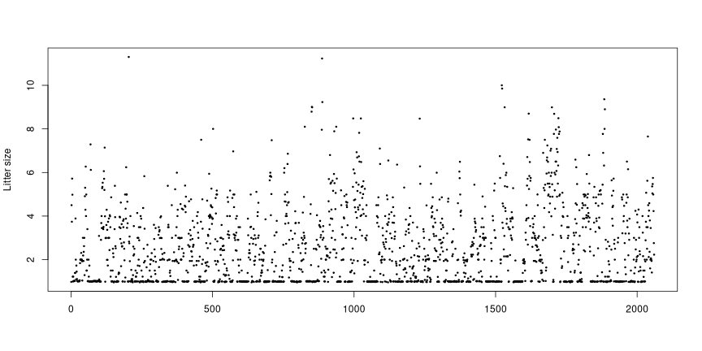

```r
plot(px$LitterSize, xlab='', ylab='Litter size', pch=20, cex=0.5)
```

## Points, sorted

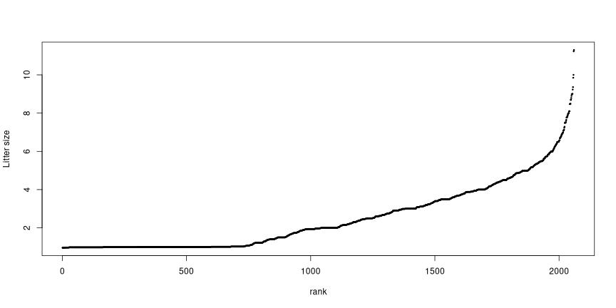

```r
plot(sort(px$LitterSize), xlab='rank', ylab='Litter size', pch=20, cex=0.5)
```

## Points, sorted and colored

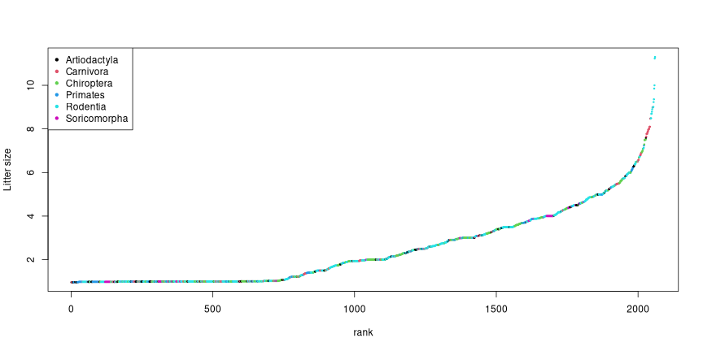

```r
plot(sort(px$LitterSize), col=px$Order, xlab='rank', ylab='Litter size', pch=20, cex=0.5)
legend("topleft", pch=20, col=1:nlevels(px$Order), legend=levels(px$Order))
```

## Histogram

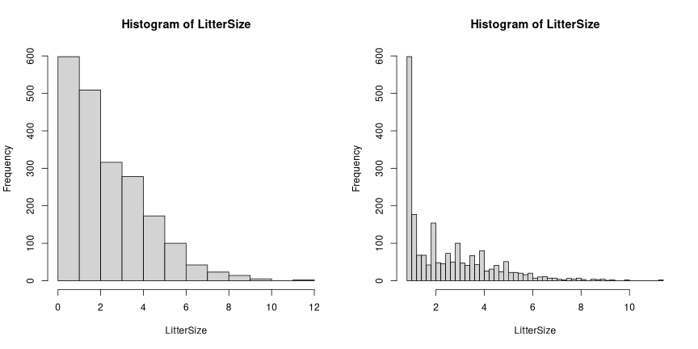

```r
layout(t(1:2))
with(px, hist(LitterSize))
with(px, hist(LitterSize, breaks=40))
```

## Histograms

```r
layout(matrix(1:6, ncol=3, byrow=TRUE), heights=c(1, 1.2))
opar <- par(mar=c(1, 4, 1, 1)+.1)
xh <- hist(px$LitterSize, plot=FALSE, breaks=30)
for (k in 1:nlevels(px$Order)) {
    ord <- levels(px$Order)[k]
    if (k == 4) par(opar)
    with(subset(px, Order == ord),
        hist(LitterSize, xlim=c(0, max(px$LitterSize)),
             breaks=xh$breaks, main=ord,
             xaxt=if (k > 3) 's' else 'n',
             xlab=if (k > 3) 'litter size' else '') )
}
```

## Histograms

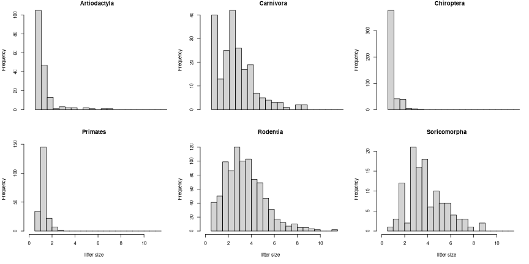

## Overlaid histograms

```r
overlay_hist <- function (x, f, breaks=30, ...) {
    xh <- hist(x, breaks=breaks, plot=FALSE)
    ymax <- do.call(max, with(px, lapply(tapply(LitterSize, Order, hist, plot=FALSE), "[[", "counts")))
    for (k in 1:nlevels(f)) {
        hist(x[f==levels(f)[k]], breaks=xh$breaks, ...,
             add=(k>1), col=adjustcolor(k, 0.4), ylim=c(0, ymax))
    }
    legend("topright", fill=adjustcolor(1:nlevels(f), 0.4),
           legend=levels(f))
}
```

## Overlaid histograms

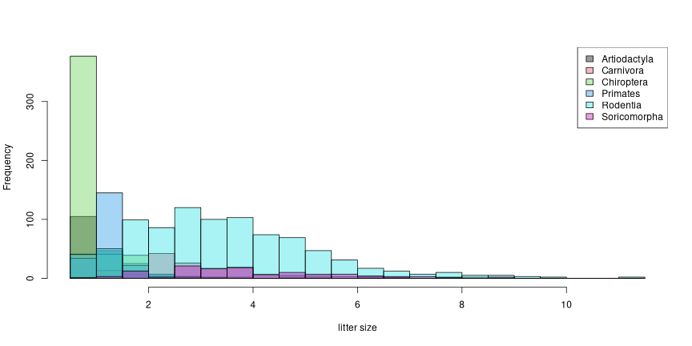

```r
with(px, overlay_hist(LitterSize, Order, xlab='litter size', main=''))
```

## boxplots

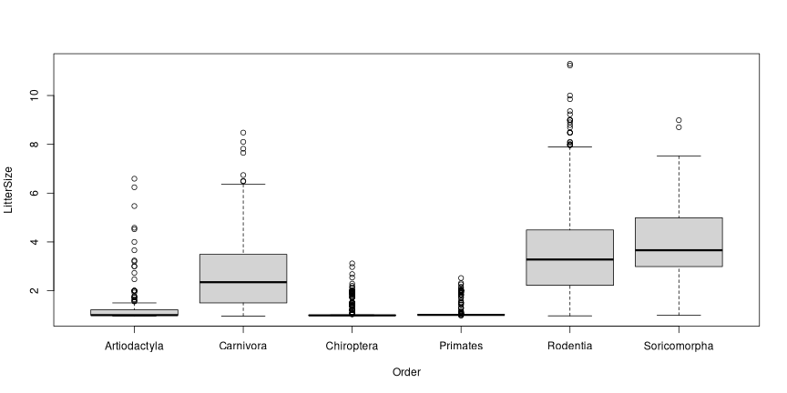

introduced by [Mary Eleanor Spear](https://en.wikipedia.org/wiki/Mary_Eleanor_Spear)

```r
boxplot(LitterSize ~ Order, data=px)
```

## Many boxes

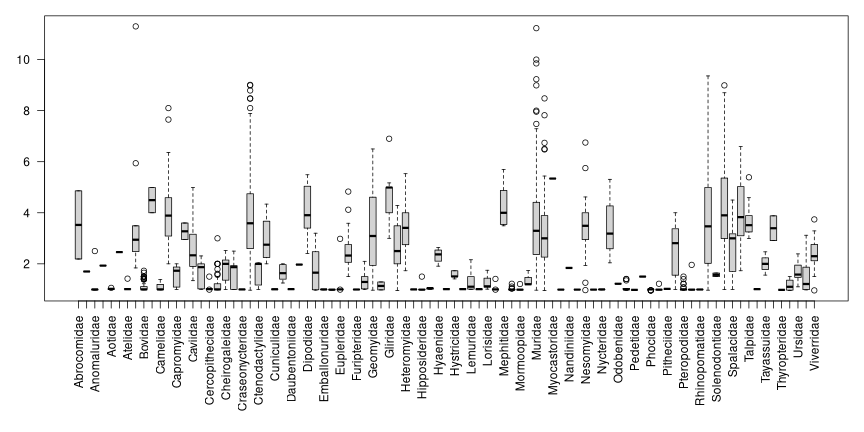

```r
par(mar=c(9, 3, 1, 1) + 0.1)
boxplot(LitterSize ~ Family, las=2, xlab='', data=px)
```

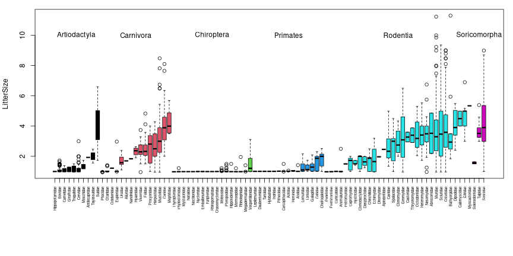

```r
par(mar=c(9, 4, 1, 1) + 0.1)
famsize <- aggregate(LitterSize ~ Order + Family, data=px, mean)
famorder <- rank(with(famsize, LitterSize + 100 * as.numeric(Order)), ties.method='first')
boxplot(LitterSize ~ Family, data=px, xlab='',
                 col=as.numeric(famsize$Order),
                 at=famorder, xaxt='n')
axis(1, at=famorder, labels=levels(px$Family), cex.axis=0.5, las=2)
text(x=tapply(famorder, famsize$Order, mean),
     y=10, label=levels(famsize$Order))
```

## Your turn

*Challenge:* visualize `LitterSize` by `TeatNumber`, using a boxplot.

# The Grammar of Graphics

## or, “`gg`”

- introduced by [Leland Wilkinson](https://www.springer.com/gp/book/9780387245447)
- adopted by [Hadley Wickham](http://hadley.nz/) in the `ggplot` library
- thinks of plots as *objects*
- see [this chapter](https://r4ds.had.co.nz/data-visualisation.html) of *R for Data Science*

## Ingredients of a visualization

- data
- coordinate axes
- a `geom`etric representation of numbers
- a mapping from (summaries of) variables to properties of the geoms
- maybe more plots

## basic template

```r
ggplot(data = <DATA>) +
  <GEOM_FUNCTION>(mapping = aes(<MAPPINGS>))
```

## more options

```r
ggplot(data = <DATA>) +
  <GEOM_FUNCTION>(
     mapping = aes(<MAPPINGS>),
     stat = <STAT>,
     position = <POSITION>
  ) +
  <COORDINATE_FUNCTION> +
  <FACET_FUNCTION>
```

*Reference:* the [ggplot2 book](https://ggplot2-book.org/index.html).

## Points

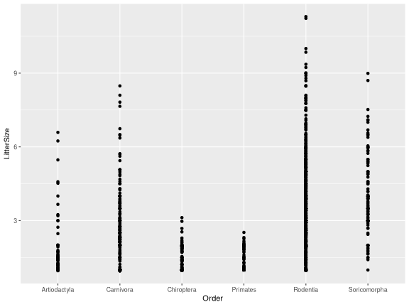

```r
ggplot(px, mapping=aes(x=Order, y=LitterSize)) + geom_point()
```

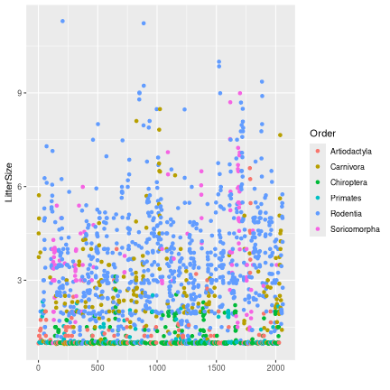

```r
(ggplot(px,
        mapping=aes(x=1:nrow(px),
                    y=LitterSize,
                    col=Order))
 + xlab("")
 + geom_point())
```

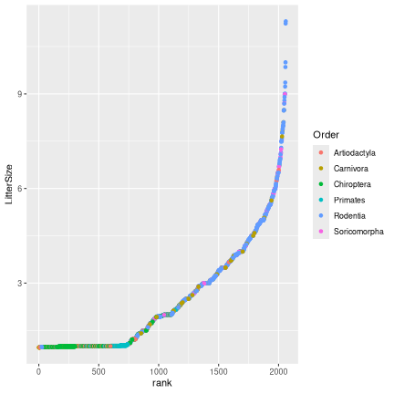

```r
(ggplot(px,
        mapping=aes(x=rank(LitterSize,
                           ties.method='first'),
                    y=LitterSize,
                    col=Order))
 + xlab("rank")
 + geom_point())
```

## Histogram

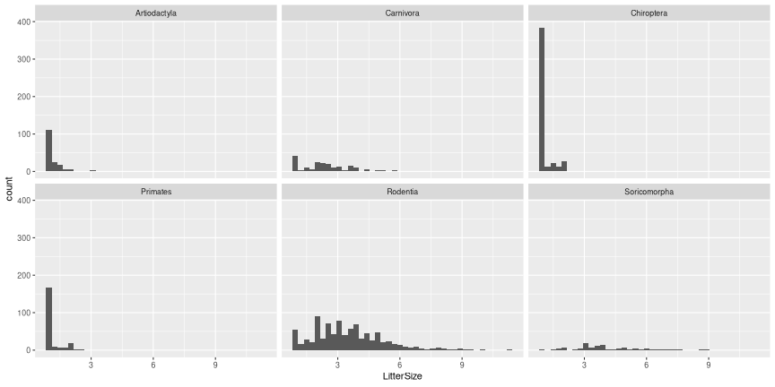

```r
ggplot(px, mapping=aes(LitterSize)) + geom_histogram(bins=40) + facet_wrap(~ Order)
```

## Histogram, stacked

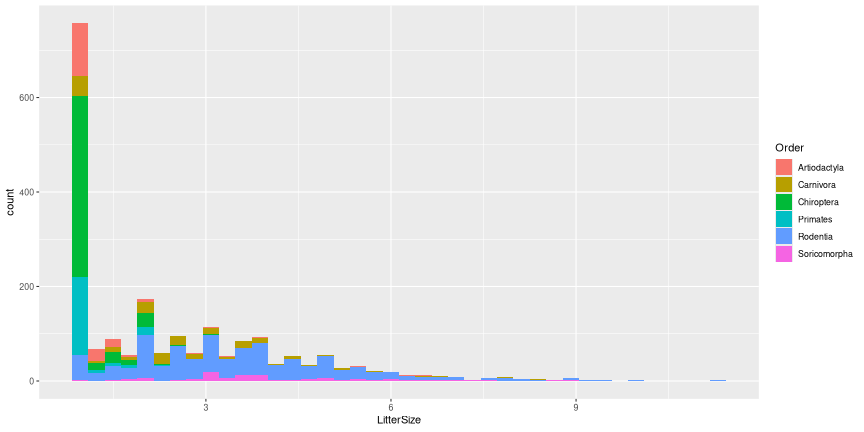

```r
ggplot(px, mapping=aes(LitterSize, fill=Order)) + geom_histogram(bins=40)
```

## Boxplot

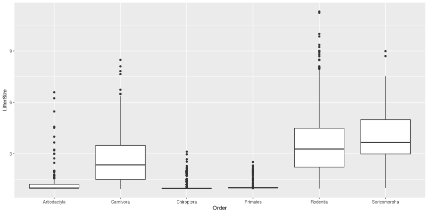

```r
ggplot(px, mapping=aes(y=LitterSize, x=Order)) + geom_boxplot()
```

## Many boxplots

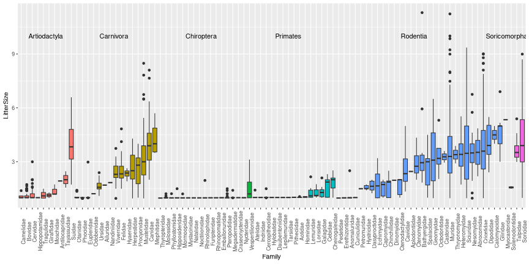

```r
by_fam <- px |> summarise(LitterSize=median(LitterSize), .by=c(Order, Family)) |>
    arrange(Order, LitterSize)
by_order <- by_fam |> mutate(j=row_number()) |>
    summarise(LitterSize=mean(LitterSize), pos=mean(j)*.98, .by=Order)
px |> mutate(Family=fct_relevel(Family, as.character(by_fam$Family))) |>
    ggplot(aes(y=LitterSize, x=Family, fill=Order)) +
    geom_boxplot() + theme(legend.position="none") +
    annotate("text", x=by_order$pos, y=10, label=by_order$Order) +
    theme(axis.text.x = element_text(angle = 90))
```

## Your turn, again

*Challenge:* make this plot.

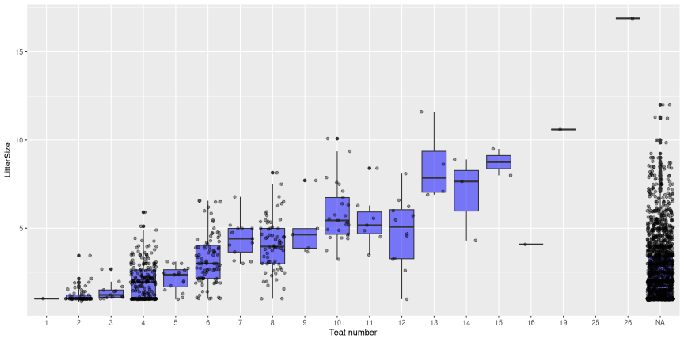

The [cheatsheet](https://rstudio.github.io/cheatsheets/html/data-visualization.html) might be helpful.